# Titanic Data Sets and RandomForests

Trey Beeman

December 9, 2016

# **1 Introduction**

### **1.1 Abstract**

This document is being created to learn `randomForests` working with data from Kaggle competitions. Thanks to Kaggle.com and Datacamp.com for the information and guidance in preparing this document. I relied heavily on this source (https://www.kaggle.io/svf/198371/166ea2e9c1074ca9cd2447c7ee27cf10/__results__.html#prediction) in order to work through the feature engineering techniques.

### **1.2 Libraries**

This is an exhaustive list of all libraries used for this project.

```r
library(ggplot2)
library(dplyr)
library(randomForest)
library(rpart)
library(caret)
library(rattle)
library(rpart.plot)
library(mice)
library(RColorBrewer)
```

# **2 Data**

We read the data sets into R. The data can be found at the links in the code block.

```r
# create url strings
train_url <- "http://s3.amazonaws.com/assets.datacamp.com/course/Kaggle/train.csv"
test_url <- "http://s3.amazonaws.com/assets.datacamp.com/course/Kaggle/test.csv"

# read the data in to R.
train <- read.csv(train_url, stringsAsFactors = FALSE)
test <- read.csv(test_url, stringsAsFactors = FALSE)

# combine the data into a single dataframe for feature engineering
df <- bind_rows(train,test)
```

### **2.1 Exploratory Data Analysis**

We take a look at the data to gain insight into what can be pulled out of it.

A `str()` of the data with an overview of the data, class and variabe names.

```
## 'data.frame':    1309 obs. of  12 variables:
##  $ PassengerId: int  1 2 3 4 5 6 7 8 9 10 ...
##  $ Survived   : int  0 1 1 1 0 0 0 0 1 1 ...
##  $ Pclass     : int  3 1 3 1 3 3 1 3 3 2 ...
##  $ Name       : chr  "Braund, Mr. Owen Harris" "Cumings, Mrs. John Bradley (Florence Briggs Thayer)" "Heikkinen, Miss. Laina" "Futrelle, Mrs. Jacques Heath (Lily May Peel)" ...
##  $ Sex        : chr  "male" "female" "female" "female" ...
##  $ Age        : num  22 38 26 35 35 NA 54 2 27 14 ...
##  $ SibSp      : int  1 1 0 1 0 0 0 3 0 1 ...
##  $ Parch      : int  0 0 0 0 0 0 0 1 2 0 ...
##  $ Ticket     : chr  "A/5 21171" "PC 17599" "STON/O2. 3101282" "113803" ...
##  $ Fare       : num  7.25 71.28 7.92 53.1 8.05 ...
##  $ Cabin      : chr  "" "C85" "" "C123" ...
##  $ Embarked   : chr  "S" "C" "S" "S" ...
```

We will highlight a few useful or interesting facts from the data.

This is a proportion table of the survivors by `Sex`.

```
##
##                  0         1
##   female 0.2579618 0.7420382
##   male   0.8110919 0.1889081
```

This is a proportion table of survivors by Passenger Class `Pclass`.

```
##
##             0         1
##   1 0.3703704 0.6296296
##   2 0.5271739 0.4728261
##   3 0.7576375 0.2423625
```

##### **2.1.1 The Passengers**

The mean age of all passengers is:

```
## [1] 29.88114
```

The mininum age of all passengers is:

```
## [1] 0.17
```

The maxinum age of all passengers is:

```
## [1] 80
```

##### **2.2.2 The Survivors**

The mean age of survivors is:

```
## [1] 28.34369
```

The mininum age of survivors:

```
## [1] 0.42
```

The maximum age of survivors:

```
## [1] 80
```

### **2.2 Exploratory Graphs**

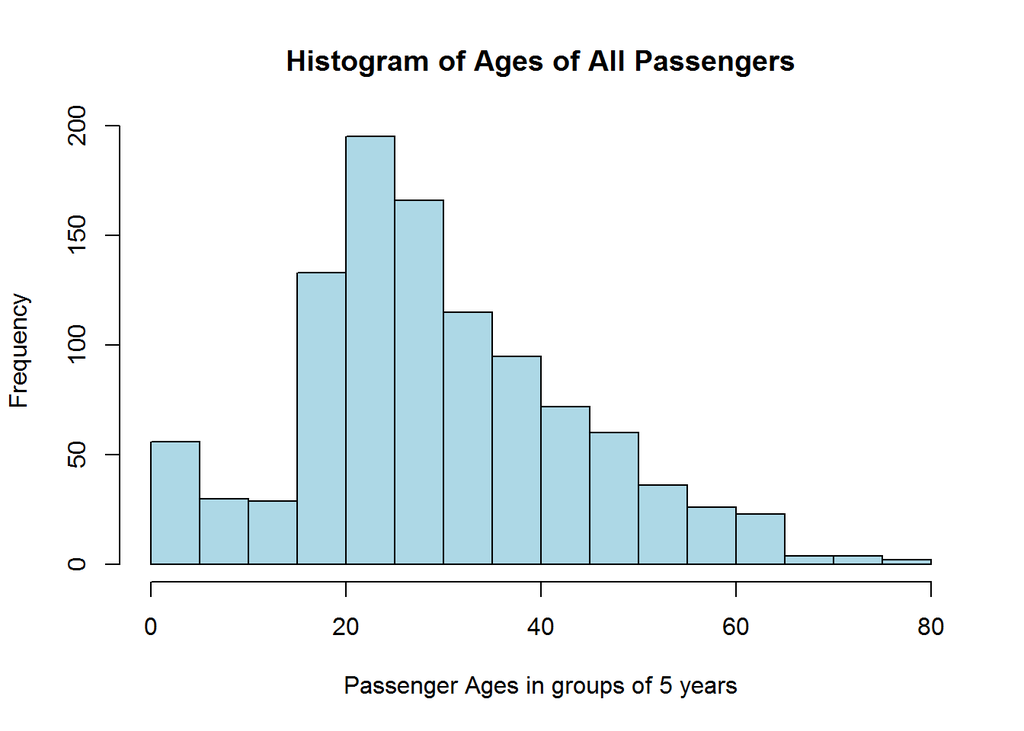

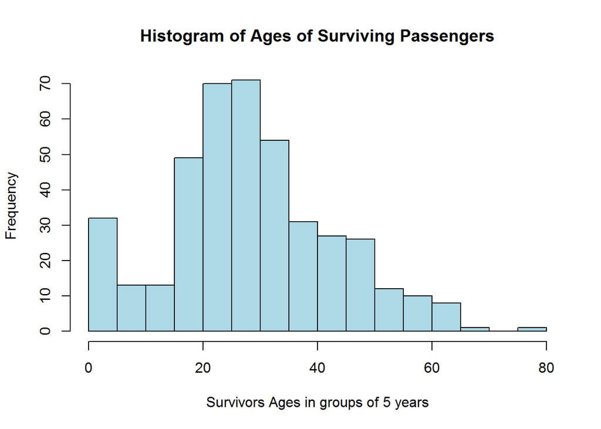

# **3 Feature Engineering**

### **3.1 Names**

We will create or **feature engineer** a new variable based first on names. We create a `Title` variable.

```r
# pull the title out of the passenger names
df$Title <- gsub('(.*, )|(\\..*)', '', df$Name)

table(df$Sex, df$Title)
```

```
##
##          Capt Col Don Dona  Dr Jonkheer Lady Major Master Miss Mlle Mme
##   female    0   0   0    1   1        0    1     0      0  260    2   1
##   male      1   4   1    0   7        1    0     2     61    0    0   0
##
##           Mr Mrs  Ms Rev Sir the Countess
##   female   0 197   2   0   0            1
##   male   757   0   0   8   1            0
```

First, we will quickly clean up the titles with are synonyms and congnates.

```r
df$Title[df$Title == "Ms"] <- "Miss"
df$Title[df$Title == "Mlle"] <- 'Miss'
df$Title[df$Title == "Mme"] <- 'Mrs'
```

With the remaining, we will divide them into classes of **nobility, military, Dr** and **Rev** in order to preserve the information in these titles.

```r
nobility <- c("Don", "Dona", "Jonkheer", "Lady", "Sir", "the Countess")
military <- c("Capt", "Col", "Major")

df$Title[df$Title %in% nobility] <- "Nobility"
df$Title[df$Title %in% military] <- "Military"
```

It is interesting to note that all the individuals with the title **Rev** did not survive.

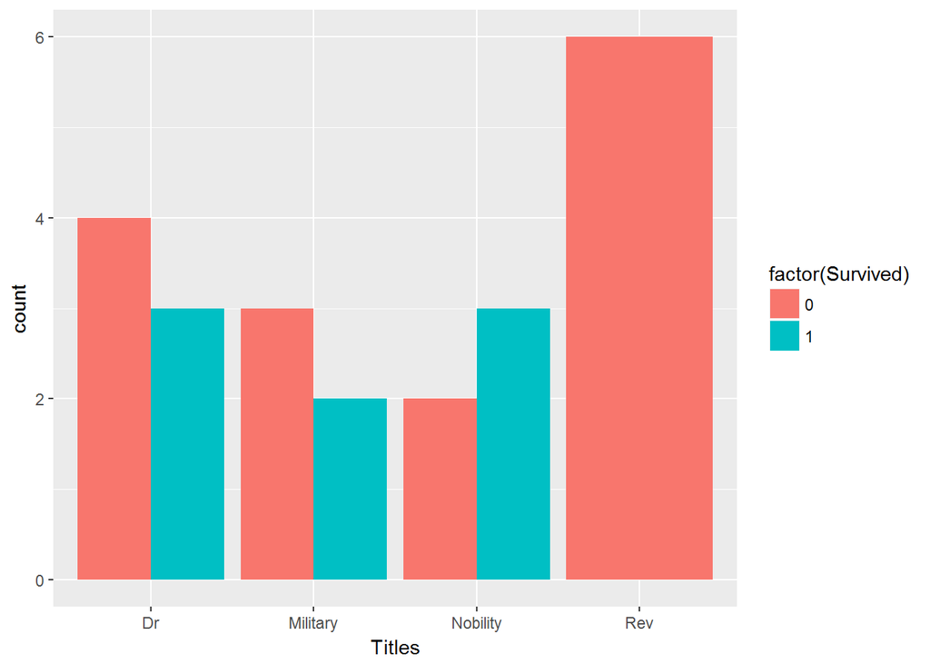

### **3.2 Families**

We want to examine the hypothesis that families are likely to move together as a group, therefore, their survivorship may differ from an individual travelling alone. We will create `family_size` variable to indicate a family travelling together.

```r
# create a new variable, family_size
df$family_size <- df$SibSp + df$Parch + 1

# create Surname variable
df$Surname <- sapply(df$Name, function(x) strsplit(x, split = '[,.]')[[1]][1])

# Create a family variable identifying a group travelling together
df$Family <- paste(df$Surname, df$family_size, sep='_')
```

We can see that individuals and familes greater than 4 had a lower survivorship than other groups.

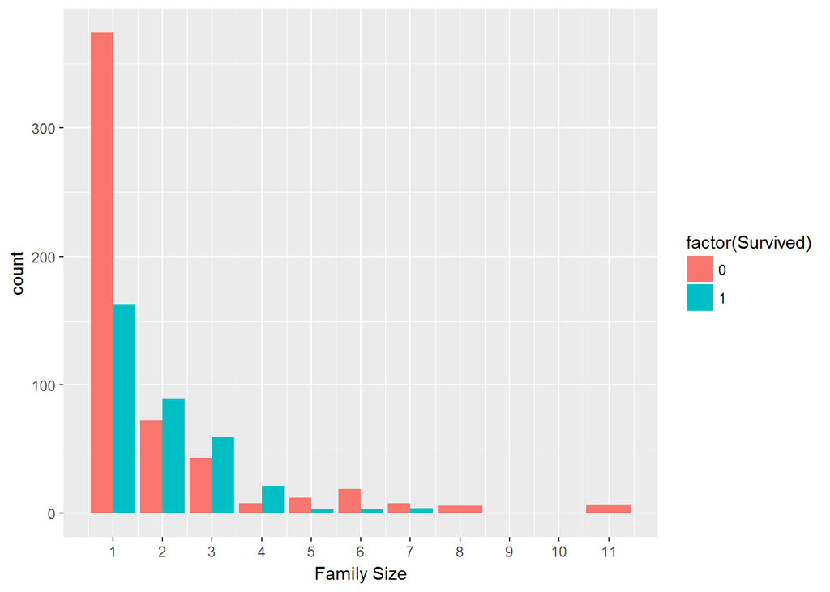

```r
ggplot(data = subset(df, !is.na(df$Survived)), aes(x = family_size, fill = factor(Survived))) + geom_bar(stat='count', position='dodge') + scale_x_continuous(breaks=c(1:11)) + labs(x = 'Family Size')
```

We are going to created a **discretized** variable on family size in order to examine this data a little more closely.

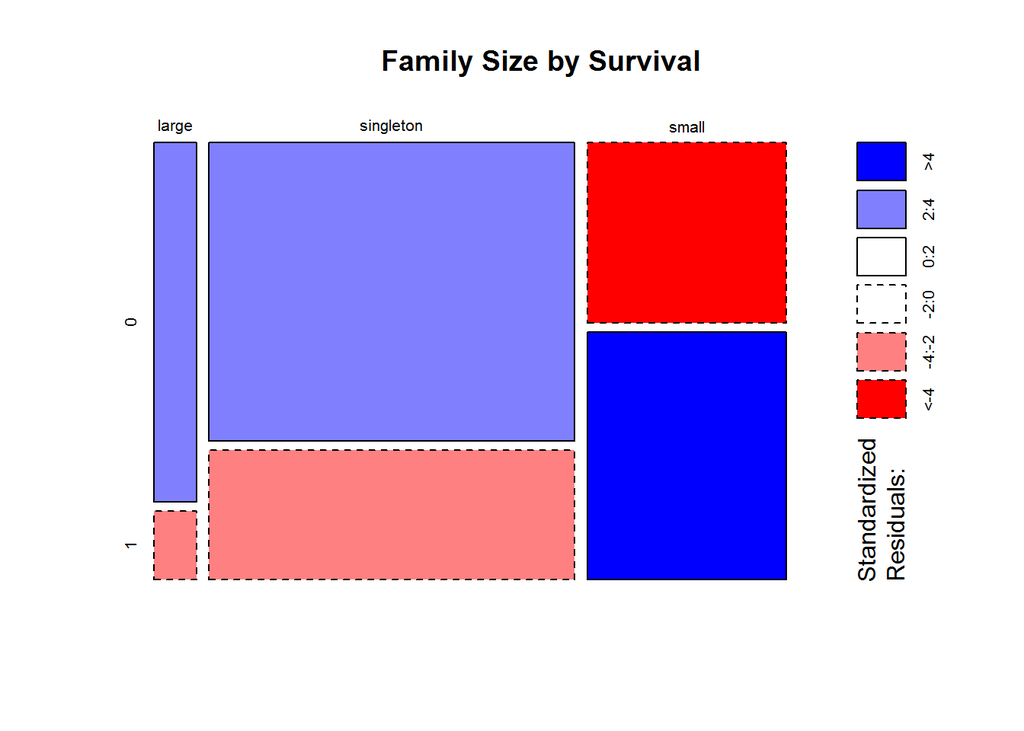

```r
# create the vatiables
df$Disfamily_size[df$family_size == 1] <- 'singleton'
df$Disfamily_size[df$family_size < 5 & df$family_size > 1] <- 'small'
df$Disfamily_size[df$family_size > 4] <- 'large'

# mosaicplot of the
mosaicplot(table(df$Disfamily_size, df$Survived), main='Family Size by Survival', shade=TRUE)
```

The mosaic plot confirms our hyopthesis that there is a penalty for individuals and large families.

### **3.3 Cabin**

We will create a variable for the Deck based on the information about the cabin assignments.

```r
df$Deck <- factor(sapply(df$Cabin, function(x)  strsplit(x, "")[[1]][1]))
```

# **4 Missing Values**

### **4.1 Simple Value Imputation**

In order to continue we need to deal with missing values. First, we look at where they are missing values.

```r
# search for blanks
sapply(df, function(x) sum(grepl("^$", x)))
```

```
##    PassengerId       Survived         Pclass           Name            Sex
##              0              0              0              0              0
##            Age          SibSp          Parch         Ticket           Fare
##              0              0              0              0              0
##          Cabin       Embarked          Title    family_size        Surname
##           1014              2              0              0              0
##         Family Disfamily_size           Deck
##              0              0              0
```

```r
# search for NAs
sapply(df, function(x) sum(is.na(x)))
```

```
##    PassengerId       Survived         Pclass           Name            Sex
##              0            418              0              0              0
##            Age          SibSp          Parch         Ticket           Fare
##            263              0              0              0              1
##          Cabin       Embarked          Title    family_size        Surname
##              0              0              0              0              0
##         Family Disfamily_size           Deck
##              0              0           1014
```

We start small. **Embarked** is missing two values.

```r
# which values are missing
which(grepl("^$", df$Embarked) == TRUE)
```

```
## [1]  62 830
```

```r
# examine the data
df[62,]
```

```
##    PassengerId Survived Pclass                Name    Sex Age SibSp Parch
## 62          62        1      1 Icard, Miss. Amelie female  38     0     0
##    Ticket Fare Cabin Embarked Title family_size Surname  Family
## 62 113572   80   B28           Miss           1   Icard Icard_1
##    Disfamily_size Deck
## 62      singleton    B
```

```r
df[830,]
```

```
##     PassengerId Survived Pclass                                      Name
## 830         830        1      1 Stone, Mrs. George Nelson (Martha Evelyn)
##        Sex Age SibSp Parch Ticket Fare Cabin Embarked Title family_size
## 830 female  62     0     0 113572   80   B28            Mrs           1
##     Surname  Family Disfamily_size Deck
## 830   Stone Stone_1      singleton    B
```

Looking at the data there is an interesting coincidence, these ladies shared a cabin. In this case, given the small number of changes, an investigation into the names revealed that there is documentation of these ladies. Ms. Icard was Mrs. Stone’s maid and they boarded Titanic at Southhampton per this website (https://www.encyclopedia-titanica.org/titanic-survivor/martha-evelyn-stone.html)

In this instance, we will assign the values based on this information.

```r
df$Embarked[62] <- df$Embarked[830] <- "S"
```

**Fare** is missing one value.

```r
# examine the data
df[which(is.na(df$Fare) == TRUE),]
```

```
##      PassengerId Survived Pclass               Name  Sex  Age SibSp Parch
## 1044        1044       NA      3 Storey, Mr. Thomas male 60.5     0     0
##      Ticket Fare Cabin Embarked Title family_size Surname   Family
## 1044   3701   NA              S    Mr           1  Storey Storey_1
##      Disfamily_size Deck
## 1044      singleton <NA>
```

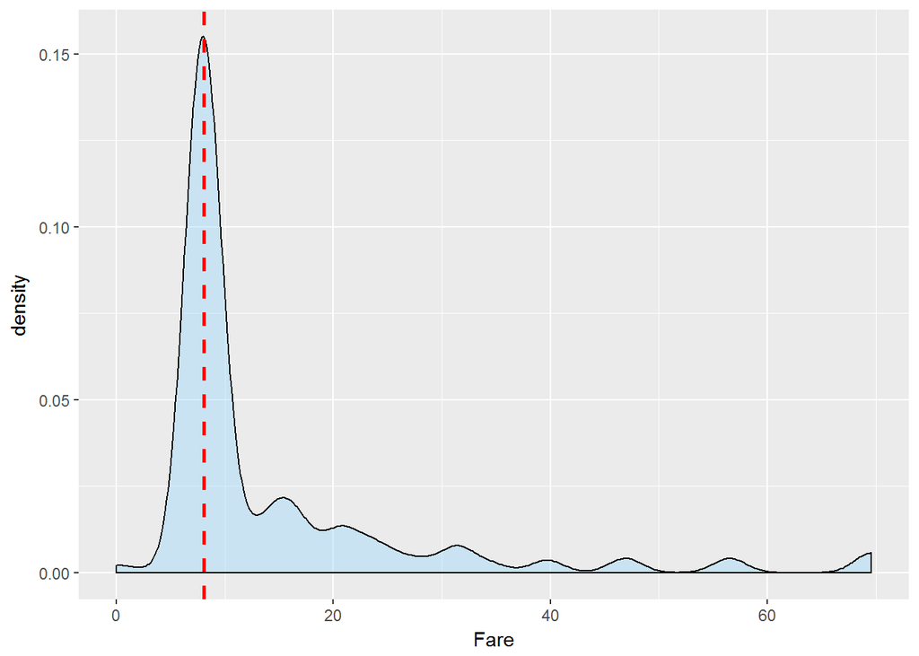

```r
ggplot(df[df$Pclass == '3' & df$Embarked == 'S', ], aes(x = Fare)) +
   geom_density(fill = '#99d6ff', alpha=0.4) +
   geom_vline(aes(xintercept=median(Fare, na.rm=TRUE)),
              colour='red', linetype='dashed', lwd=1)
```

Mr. Storey departed from Southhamptom and travelled 3rd class, so we will use those variables to base an imputation. It appears reasonable to assume the median for his **Pclass** and **Embarked** values.

```r
df$Fare[1044] <- median(df[df$Pclass == "3" & df$Embarked == "S",]$Fare, na.rm = TRUE)
```

### **4.2 Age**

We tackle **Age** next which has 263 missing values. We will use predicitve imputation via the `mice` package.

```r
# coerce variables to factors
factor_vars <- c("PassengerId", "Pclass", "Sex", "Embarked", "Title", "Surname", "Family", "Disfamily_size")

df[factor_vars] <- lapply(df[factor_vars], function(x) as.factor(x))

set.seed(129)

mice_mod <- mice(df[, !names(df) %in% c('PassengerId','Name','Ticket','Cabin','Family','Surname','Survived')], method="rf")
mice_output <- complete(mice_mod)
```

Now, we compare the distruibution of the imputed values with the observed values.

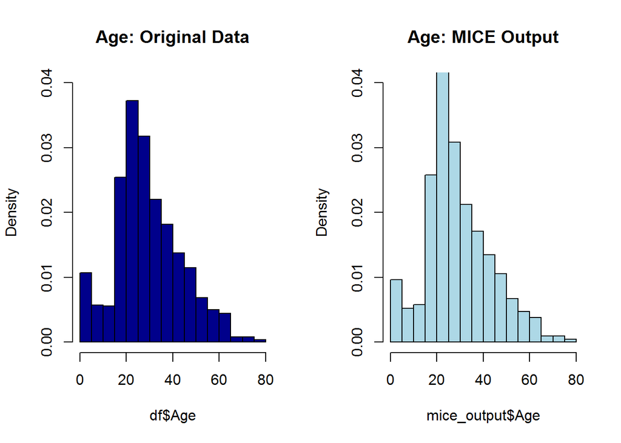

```r
# hist of age distributions
par(mfrow=c(1,2))
hist(df$Age, freq=FALSE, main='Age: Original Data',
  col='darkblue', ylim=c(0,0.04))
hist(mice_output$Age, freq=FALSE, main='Age: MICE Output',
  col='lightblue', ylim=c(0,0.04))
```

The distributions are very close, so we proceed with adding the values to `df`.

```r
# save the mice output to df
df$Age <- mice_output$Age

sum(is.na(df$Age))
```

```
## [1] 0
```

This concludes the imputing that we care about at this point. *(revisit later??)*

### **4.3 Feature Engineering Part Two**

Now, we create age dependent variables **Child** and **Mother**.

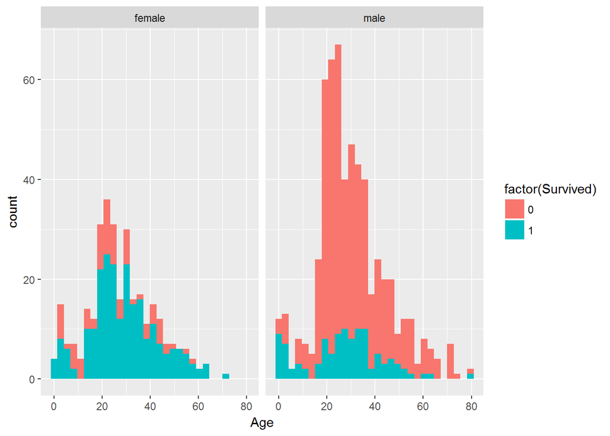

```r
# First we'll look at the relationship between age & survival
ggplot(df[1:891,], aes(Age, fill = factor(Survived))) +
  geom_histogram() + facet_grid(.~Sex)
```

```r
# create child variable
df$Child[df$Age < 18] <- 'Child'
df$Child[df$Age >= 18] <- 'Adult'

# table counts
table(df$Child, df$Survived)
```

```
##
##           0   1
##   Adult 481 276
##   Child  68  66
```

So there is even odds of survival for children. Now we will create a **Mother** variable.

```r
# create mother variable
df$Mother <- "Not Mother"
df$Mother[df$Sex == "female" & df$Parch > 0 & df$Age > 18 & df$Title != "Miss"] <- "Mother"

# table of counts
table(df$Mother, df$Survived)
```

```
##
##                0   1
##   Mother      16  39
##   Not Mother 533 303
```

```r
# coerce to factor variables
df$Child <- factor(df$Child)
df$Mother <- factor(df$Mother)
```

We will check for missing data using the `md.pattern` function.

```r
md.pattern(df)
```

```
##     PassengerId Pclass Sex Age SibSp Parch Fare Embarked Title family_size
## 150           1      1   1   1     1     1    1        1     1           1
##  61           1      1   1   1     1     1    1        1     1           1
##  54           1      1   1   1     1     1    1        1     1           1
## 511           1      1   1   1     1     1    1        1     1           1
##  30           1      1   1   1     1     1    1        1     1           1
## 235           1      1   1   1     1     1    1        1     1           1
## 176           1      1   1   1     1     1    1        1     1           1
##  92           1      1   1   1     1     1    1        1     1           1
##               0      0   0   0     0     0    0        0     0           0
##     Surname Family Disfamily_size Child Mother Ticket Survived Deck Name
## 150       1      1              1     1      1      1        1    1    0
##  61       1      1              1     1      1      1        0    1    0
##  54       1      1              1     1      1      0        1    1    0
## 511       1      1              1     1      1      1        1    0    0
##  30       1      1              1     1      1      0        0    1    0
## 235       1      1              1     1      1      1        0    0    0
## 176       1      1              1     1      1      0        1    0    0
##  92       1      1              1     1      1      0        0    0    0
##           0      0              0     0      0    352      418 1014 1309
##     Cabin
## 150     0    2
##  61     0    3
##  54     0    3
## 511     0    3
##  30     0    4
## 235     0    4
## 176     0    4
##  92     0    5
##      1309 4402
```

We will proceed with modelling with this data.

# **5 Modelling**

### **5.1 Split data into training and test sets**

```r
train <- df[1:891,]
test <- df[892:1309,]
```

### **5.2 A Decision Tree**

We will begin by looking at a decision tree for important clusters of data.

[figure not shown]

```r
# decision tree
D.tree <- rpart(Survived ~ Pclass + Sex + Age + SibSp + Parch + Fare + Embarked + Title + Disfamily_size + Child + Mother, data = train, method = "class")

# Fancy plot the decision tree
par(mfrow=c(1,1))
fancyRpartPlot(D.tree)
```

The decision tree indicates that **Title** and **Pclass** are the most important variables. Next, we run a random forest.

### **5.3 Random Forest Model**

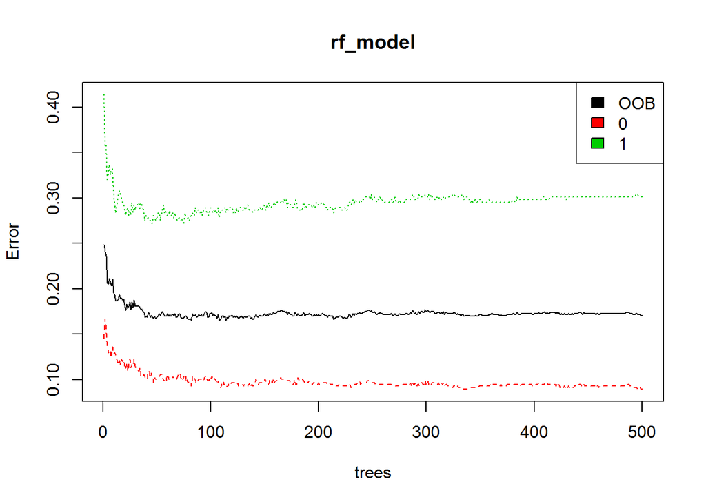

```r
# set the seed
set.seed(111)

# Apply the Random Forest Algorithm
rf_model <- randomForest(factor(Survived) ~ Pclass + Sex + Age + SibSp + Parch + Fare + Embarked + Title + Disfamily_size + Child + Mother, data = train)

# show model error
plot(rf_model)
legend("topright", colnames(rf_model$err.rate), col = 1:3, fill = 1:3)
```

Our model appears to get a little worse at predicting survival. That may be something to look at later for improvement. We are improve at predicting death.

The most important variables are as follows.

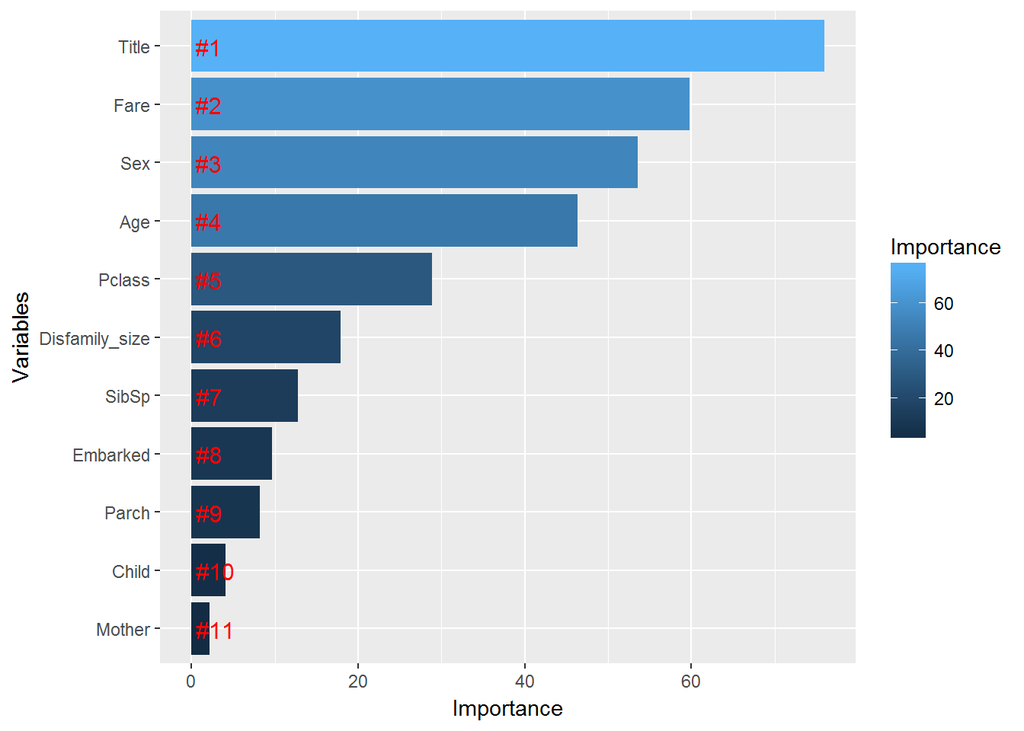

```r
# variable importance
importance    <- importance(rf_model)
varImportance <- data.frame(Variables = row.names(importance), Importance = round(importance[ ,'MeanDecreaseGini'],2))

# create a rank variable based on importance
rankImportance <- varImportance %>% mutate(Rank = paste0('#',dense_rank(desc(Importance))))

# Use ggplot2 to visualize the relative importance of variables
ggplot(rankImportance, aes(x = reorder(Variables, Importance), y = Importance, fill = Importance)) + geom_bar(stat='identity') + geom_text(aes(x = Variables, y = 0.5, label = Rank),hjust=0, vjust=0.55, size = 4, colour = 'red') + labs(x = 'Variables') + coord_flip()
```

Versus Megan Risdal’e’s model, **Fare** and **Sex** have traded priority. **Title** is the most important which is means the feature engineering was successful.

### **5.4 Prediction**

We create a prediction set to submit to Kaggle.

```r
# create prediction from the test set
prediction <- predict(rf_model, test)

# create a data frame with PassengerId and Survived
solution <- data.frame(PassengerId = test[,1], Survived = prediction)

# Write solution to a csv file
write.csv(solution, file = "solution_rf1.csv", row.names = FALSE)
```